# Climate Records, Alpine Environments, and Coastal Impacts

Uneven Knowledge and Impacts

EA30 Students, Pomona College

August 06, 2020

Updated: 2020-08-06 01:04:57

# Introduction

## Weather Records and Climate Trends

[figure not shown]

Establishing and maintaining consistently designed weather stations requires institutional capacity. In many cases, the weather stations are a symbol of and component of modernity.

However, as Bruno Latour has noted the process to modernize is both uneven and inconsistent (Latour 2012; Pachauri et al. 2015). And as we look to use weather stations, which had been established answer specific local questions, e.g. when will there be enough water to plant rice or warm enough to sow corn. But as we try to evaluate how the ``average weather" or climate might be changing we learn about how complex it is to use these weather stations.

Latour, Bruno. 2012. *We Have Never Been Modern*. Harvard university press.

Pachauri, Rajendra K, Leo Meyer, Gian-Kasper Plattner, Thomas Stocker, and others. 2015. *IPCC, 2014: Climate Change 2014: Synthesis Report. Contribution of Working Groups I, Ii and Iii to the Fifth Assessment Report of the Intergovernmental Panel on Climate Change*. IPCC.

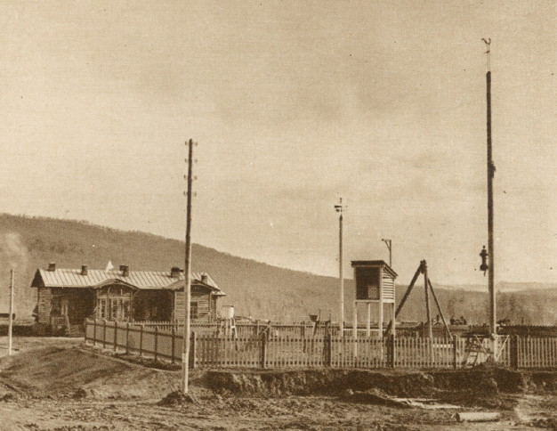

This weather station was established in 1881 as part of the construcion of the trans-Siberia railroad . The meteorological station was built by the passenger terminal at the Amazar Station

Meanwhile weather stations in remote locations, such as Glacier National Park have been moved so often, that developing a long-term trend might seem impossible Foster (2019).

# Climate Change in High Elevation Locations

## Alpine Environments

Zurich, a city in northern Switzerland, is a unique masterpiece of the world. Situated next to a gorgeous lake with magnificent Swiss alps in view, Zurich is home to a substantial number of environmental lovers, groups, and institutions.

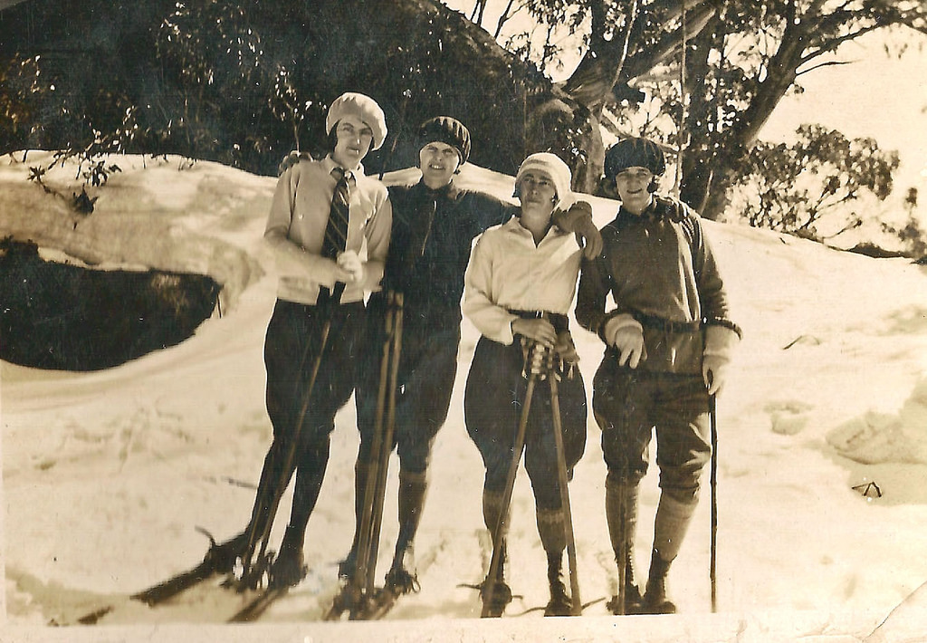

Skiers between the 1920s and 1930s

Denver changes is known to have highly variable weather. Thus, Bidell (2019) evaluated if there has been an increase in variability. Granted that the question is rather complicated, the results suggest more analysis is necessary to make a conclusive statement.

# Urban Environments

## Getting and Processing Data

As it turns out obtaining and processing the data from NOAA is far from trivial. To make the process more transparent, Hsu (2019) documented the steps taken to determine if trends exist in San Francisco. In this example, we can see the messy process of learning to analyze these data.

In addition, some data have biases – but bias does not need worthless – instead scientists work hard to remove the impacts of bias as pointed out by Piette (2019) while analyzing Seattle’s long term trends.

The temperature trend, however, are not always easy to digest. For example, Grant (2019) found minimum temperature trends in Chicago are rising at a faster rate than maximum temperature trends in the area, indicating that Chicagoans will likely endure hotter days and nights with little relief, in the future.

## Impacts and Coastal Zone Impacts

Nevertheless, for coastal zones, the impacts of climate change might be ``felt’’ in a myriad of ways, for example, sea level rise in San Francisco (Hsu 2019) and Seattle (Piette 2019) will require a dramatic investment to limit the impacts of floods, protect infrastructure, and maintain economic activities.

## Perceptions and Records

In the climate change debate, as in many conflicts, we find that our beliefs, ideals and political affiliations play a distinct role in our perceptions. This blog explores how belief for or against climate change filters public perception in different regions. For example, Whitman_Sandmeyer (2019) found that the signal for climate change in Kentucky to be challenging to determine. This, of course, ``maps’’ onto the region in particularly interesting ways in terms of politics and climate impacts.

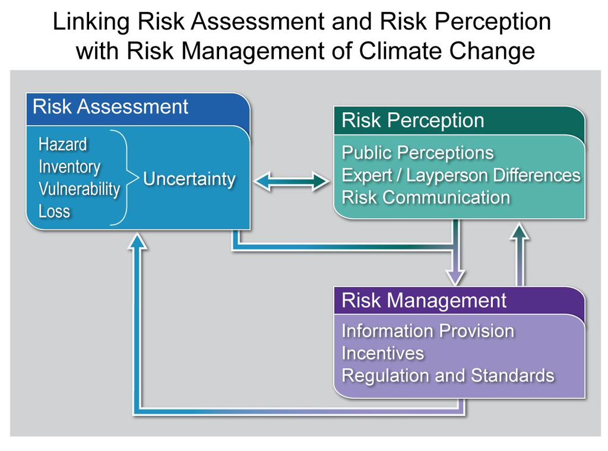

This figure highlights the importance of incorporating both experts’ assessment of the climate change risk and general public perceptions of this risk in developing risk management strategies for reducing the negative impacts of climate change.

On the west coast, the State of California has experienced record setting fires, but the relative role of climate on these is subject to debate. Mc Williams (2019) describes how complicated it is to determine the potential role of climate change on the size and severity of fires.

Overall, our sense of risk perception can play a huge role in how prioritize various potential threats

## Global Anarchy and Fair Reciprocity

The concept of climate justice has taken on a wide range of ethical frameworks which have been applied to diverse set of political and social scales. Within the nation-state governance anarchy, scholars have attempted to create moral imperatives to address climate impacts on countries that have not contributed to or enjoyed the economic rewards of greenhouse gases emissions. Using the ‘fair reciprocity’ Bekkers (2019) argues that the Netherlands should provide assistance to the Marshall Islands as the islands face potentially devastating impacts of sea level rise.

# Conclusion

Overall, the class was exceptional at picking a wide range of climate issues and documenting the how complex it is to analyze and communicate the results while at the same time attempting to be thoughtful about alternative interpretations and policy options.

## Incomplete Blogs

- Venezuela Chaichang Azterbaum (2019)

# Previous EA30 Projects

Attribution Science (Spring 2019)

Climate Change and Fires – Is this a red herring or the alarm alarmists have been warning about? (Fall 2918)

Why Climate Change Will Affect You Personally? (Fall 2017)

Climate Change and Logical Fallacies Spring 2016)